# Dispersal in a Neotropical tree, Virola flexuosa (Myristicaceae): Does hunting of large vertebrates limit seed removal? - Holbrook - 2009 - Ecology - Wiley Online Library

[Ecology](https://esajournals.onlinelibrary.wiley.com/journal/19399170)

[Volume 90, Issue 6](https://esajournals.onlinelibrary.wiley.com/toc/19399170/2009/90/6) p. 1449-1455

Report

Free Access

# Dispersal in a Neotropical tree, *Virola flexuosa* (Myristicaceae): Does hunting of large vertebrates limit seed removal?

[K. M. Holbrook](https://esajournals.onlinelibrary.wiley.com/action/doSearch?ContribAuthorRaw=Holbrook%2C+K+M),

[B. A. Loiselle](https://esajournals.onlinelibrary.wiley.com/action/doSearch?ContribAuthorRaw=Loiselle%2C+B+A),

First published: 01 June 2009

https://doi.org/10.1890/08-1332.1

Citations: 76

Check for Full Text

## Abstract

To understand how different frugivores impact dispersal, we studied the assemblage that feed on *Virola flexuosa* over a two-year period at two sites differing in hunting pressure in Ecuador. We focus on disperser effectiveness and test the hypothesis that seed removal, influenced by differential visits of large-bodied frugivores, will differ between hunted and non-hunted sites. All visiting frugivores were identified, and fruit handling behavior and seed removal rates quantified. Seed traps were placed under fruiting trees to estimate crop size and fruit removal. Seventeen bird and three primate species were recorded foraging in *V. flexuosa* trees. Toucans and primates were the most important dispersers comprising nearly 85% of visits with six toucan species recorded in 74% of visits. A proportionately larger number of seeds were removed from fruiting trees at a non-hunted site (89.4%) than a hunted site (66.8%). In addition, there were significantly more frugivore visits at the non-hunted than the hunted site. The differences in the frugivore assemblage and the number of seeds dispersed from individual trees between two structurally similar forest sites suggest dispersal limitation resulting from a decline in frugivores.

## Introduction

Vertebrate frugivores play key roles in plant recruitment by influencing the number, dispersal distance, and spatial distribution of seeds over the landscape (Jordano and Godoy 2002). These dispersal processes may be limited across a continuum of spatial and temporal scales (Jordano and Godoy 2002, Schupp et al. 2002). A seed disperser's effectiveness, measured as its contribution to plant fitness, has both qualitative and quantitative components (Schupp 1993). For example, the distance a seed is moved from the plant is qualitative, because it affects the probability that a seed will germinate and recruit to the next life stage, and the average number of seeds removed is quantitative. Quantitatively restricted seed dispersal occurs when, independent of seed production, the quantity of seeds dispersed from the parent tree is limited by disperser activity or behavior (Schupp et al. 2002). Thus, if hunting or other anthropogenic activities alter disperser abundances or behavior, the chance of seeds being dispersed may decline due to lowered numbers of dispersers or because altered habitats are no longer conducive to animal movement. This predicted decline in dispersal services is more likely to impact large-seeded species (Wright et al. 2000, Forget and Jansen 2007; see Stoner et al. 2007 for a recent review). Following reduced dispersal, attributed to a loss of vertebrate seed dispersers, one would expect seeds to be clumped under parent trees, potentially leading to shifts in seedling and/or sapling tree species composition (Nuñez-Iturri and Howe 2007, Wright et al. 2007, Terborgh et al. 2008). Here, we focus on the quantitatively restricted component of dispersal limitation, to examine seed removal of a Neotropical tree in two sites that differ in hunting pressures.

Hunting in a nonhuman disturbed forest is expected to lower abundances of large-bodied frugivores resulting in fewer visits to fruiting trees by larger seed dispersers. In the Ecuadorian Amazon, ateline primates (Atelidae), toucans (Ramphastidae), and guans (Cracidae) have been hunted extensively at a site in the Yasuní Biosphere Reserve, where as much as 34% and 39% of biomass of hunted mammals and birds, respectively, were removed in an 11-month period (Mena et al. 2000). Recent work in the Yasuní Biosphere Reserve found substantial hunting pressures at three permanent Huaorani settlements (Franzen 2006), where up to 79% of species harvested were those previously considered vulnerable to hunting (including cracids and atelines) (Bodmer et al. 1997, Mena et al. 2000). If hunting negatively affects primate and large bird abundances, then we expect that relatively fewer large frugivores will visit fruiting trees at a hunted site than non- hunted site due to lower numbers of primates, toucans, and guans. Consequently, relatively fewer seeds will be removed from trees at a hunted site.

We investigated the assemblage of frugivores that feed on *Virola flexuosa* (Myristicaceae) over a two-year period at two sites in Amazonia Ecuador that are structurally and compositionally similar, but markedly different in hunting activities. First, we measured seed removal by primates, toucans, and other avian frugivores. Then, we combined our observations at fruiting trees with data collected in fruit traps to test the hypothesis that the quantity of seeds removed from fruiting trees by large frugivores differs between sites, that is, there is quantitatively restricted seed dispersal resulting from the hunting of seed dispersal agents. We quantified hunting pressure using published literature. We predicted that fewer seeds would be removed from fruiting trees at the hunted site because of reduced numbers of visits by large-bodied frugivores, which are expected to be the more effective (i.e., large frugivores remove a higher quantity of seeds and take them farther from parent trees than small frugivores, allowing escape of density-dependent mortality) dispersers of *Virola* species (Howe and Vande Kerckhove 1981, Russo 2003). Here, focusing on the quantitative aspect of dispersal, we show significantly fewer frugivore visits and seeds removed from trees at our hunted site.

## Methods

#### Study sites

Research was conducted at the Tiputini Biodiversity Station (TBS; ∼0°38′ S, 76°09′ W) and Yasuní Research Station (YRS; ∼0°40′ S, 76°24′ W) in eastern Ecuador. The two sites, located within the Yasuní Biosphere Reserve, are 27 km apart and adjacent to the Tiputini River. Access to TBS is by river only and, consequently, it is relatively isolated from human activities and experiences no hunting by indigenous Huaorani (Karubian et al. 2005). In contrast, YRS is located along an oil access road and hunting by local Huaorani occurs near the study site (Franzen 2006). At YRS, hunting pressures steadily increased between 1994 and 1998 causing several terrestrial avian frugivores to become rare at that site (English 1998). In the last six years, hunting activities have increased dramatically due to a 2001 establishment of a Huaorani community (Tiimpuca) less than three km from the study site (Franzen 2006). At Tiimpuca, Franzen (2006) estimated yearly harvests by Huaorani to be 276–360 primates (including atelines) and 264–345 birds (including guans and toucans). These estimates are based on data collected in 2002 and it is likely the number of animals harvested in recent years has increased due to an increase in the number of hunting households from 2002 to 2005 (K. Holbrook, *personal observation*). More recently, a comparative study of primate community biomass found ateline primate densities at YRS nearly half those at TBS (Derby 2006).

Research at TBS occurred primarily within an 84-ha plot (see Holbrook and Loiselle 2007). At YRS, research was conducted in a 50-ha Forest Dynamics plot (see Valencia et al. 2004) and a 34-ha strip surrounding the plot. Both sites are dominated by terra firme forest and do not differ significantly in tree species diversity and composition (based on analysis of several 1-ha plot surveys by Pitman et al. 2001). A total of 18 female *V. flexuosa* adults were found and mapped within the two study areas (TBS, 11; YRS, 7); however, only nine trees at TBS and four at YRS produced fruit during the study period. For the purposes of examining dispersal effectiveness and dispersal limitation, each individual tree is considered the experimental unit, resulting in nine and four replicates at TBS and YRS, respectively. *Virola flexuosa* is large-seeded (∼15 × 12 mm, Appendix A) and, thus, expected to be disproportionately affected by the depletion of large-bodied frugivores. For analyses, frugivores were grouped by taxonomy, fruit handling ability, and vulnerability to hunting.

#### Frugivore assemblage and foraging behavior

We conducted observations at fruiting trees during two field seasons (2002–2004) to determine the role that frugivores play in dispersing the seeds of *V. flexuosa* (see Plate 1). *Virola* fruits dehisce during early and mid-morning hours, thus focal female trees at TBS and YRS were observed from 06:00 to 10:00 hours with a minimum of eight replications (days) per tree. The total average numbers of observation hours per tree were 34.6 for TBS and 34.0 for YRS. All visiting frugivores were identified and fruit handling behavior and fruit removal rates quantified. Fruit handling behavior includes the numbers of seeds swallowed, carried away, or dropped by individual frugivores. Fruit removal is defined as the number of seeds swallowed and taken away.

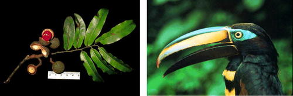

**Figure Plate 1**

Open in figure viewer[PowerPoint](https://esajournals.onlinelibrary.wiley.com/action/downloadFigures?id=i0012-9658-90-6-1449-pl01&doi=10.1890%2F08-1332.1)

(Left) *Virola flexuosa* fruit showing open capsule with bright red arillate seed inside. (Right) Toucans, like this many-banded araçari (*Pteroglossus pluricinctus*), are important seed dispersers in Neotropical forests and were found to remove up to 57% of *Virola* seeds. Photo credits: K. M. Holbrook.

For statistical analyses, visiting frugivores were put into three groups: toucans, primates, and other birds (which included Cracidae, Momotidae, and Turdidae). These three groups represented 94.5% of total visitors. Species outside these three groups individually represented <1% of foraging visits and were not included in statistical analyses. We used ANOVA to test fruit removal per visit among foraging groups (seeds consumed as the dependent variable and group as treatment). Sample sizes reflect only instances when the animal was visible and foraging behavior could be quantified; thus, sample sizes are smaller than those in calculations of total number of visits. The data for fruit handling analyses generally did not meet assumptions of normality and homogeneity of variance required for ANOVA, and standard transformations did not result in normality or homogeneity. Therefore, relationships between treatments (disperser group) and fruit handling were tested using non-parametric tests (Kruskal Wallis). If the latter test was significant, pairwise comparisons of groups were further tested using Mann-Whitney tests. Values reported are mean ± SD unless otherwise noted.

#### Crop size and seed removal efficiency

Following Howe and Vande Kerckhove (1981), seed traps (1 m<sup>2</sup>) made of PVC tubing and mosquito netting were placed underneath the canopy of each focal tree to estimate crop size and fruit removal. We positioned four to six traps, depending on tree crown size, that covered approximately 5% of the area below the crown. Every 7–10 days, we recorded all capsules (i.e., two half capsules were counted as a single capsule) and seeds that arrived in seed traps during that period. To estimate crop size, we counted the total number of capsules collected in traps and divided by the proportion of the canopy area sampled by traps. To estimate the number and proportion of seeds removed from the tree we first determined the proportion of seeds removed from seed trap data as: (total number of capsules − number of arillate seeds)/(total number of capsules); we then multiplied this by the estimated crop size to estimate the absolute number of seeds removed from each tree. This represents the absolute number of capsules from which a seed was removed.

To determine the removal efficiency of each frugivore, the number of foraging visits recorded for that species was multiplied by the average number of fruits consumed per visit, resulting in an estimate of the total number of seeds removed for that species during all observations across all trees. These estimates were summed across all species, resulting in an estimate of the total number of seeds observed to be dispersed. The estimate for each species was then divided by this sum to yield the removal efficiency of each species, relative to other dispersers.

#### Site comparisons

To determine if differences in *V. flexuosa* traits exist between TBS and YRS, we compared crop size, diameter at breast height (dbh), and crown area with two-tailed *t* tests. A nonsignificant result will permit us to test whether differences in frugivore visitation between sites are due to extrinsic factors (e.g., differences in frugivore abundance). To know whether frugivores respond to crop size in a similar way in both sites, we used linear regression to test the relationship between the number of visitors or species with crop size.

Between-site differences in the total number of visitors and species observed (based on direct observation at trees) and seed removal (seed trap studies) were tested using Mann-Whitney tests; in these tests individual trees at each site were the unit of replication. To test the hypothesis that seed dispersal is restricted quantitatively at YRS we examined variation in seed removal based on fruit and seed capture in traps and whether differences occurred in the number of frugivores visiting fruiting trees at each site. We used chi-square tests to determine differences between sites in the number of visits for toucans, primates, and other birds. We also tested site differences in fruit handling behavior between the more efficient (>50% of seeds swallowed) and less efficient (≥50% of seeds dropped) dispersers and visitation rates between hunted and non-hunted species (see Franzen 2006).

## Results

#### Frugivore assemblage and foraging behavior

Seventeen bird and three primate species were recorded foraging in *V. flexuosa* trees across both sites (Table 1). Toucans and primates were the two most important groups of visitors and comprised approximately 85% of all visits (Appendix B). Species differed in how they handled *Virola* fruits (Appendix C). Smaller visitors (e.g., thrushes, barbets, cotingas) tended to peck at the fruit to obtain the aril rather than swallow the seed. Larger species (e.g., toucans, guans, primates) were legitimate dispersers in that the majority of seeds (60–85%) were consumed and carried away from fruiting trees. Primates consumed more seeds per visit than did toucans or other avian visitors (primates, 6.4 ± 7.4; toucans, 1.5 ± 1.8; other birds, 0.9 ± 0.9; *F*<sub>2, 190</sub> = 28.01, *P* < 0.001; Tukey tests, *P* < 0.001) (Table 1). Primates dropped more seeds per visit (2.1 ± 3.8) than did toucans (0.3 ± 0.5; *U* = 800.0, *P* < 0.001) but not more than other avian dispersers (0.7 ± 0.8; *U* = 178.0, *P* = 0.073). Four species (*R. tucanus*, *A. belzebuth*, *L. lagotricha*, and *P. pluricinctus*) were responsible for removing an estimated 74% of seeds averaged over all sampled trees (Table 1).

Table 1. Visitation and seed removal by dispersers of *Virola flexuosa*.

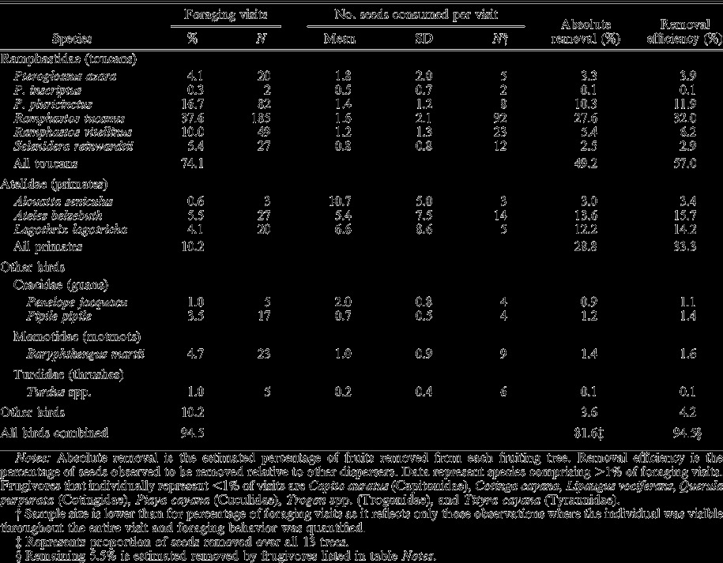

#### Crop size, seed removal efficiency, and site comparisons

Examination of *V. flexuosa* plant traits showed no differences in crop size, crown area, or diameter at breast height (dbh) between trees at TBS and YRS (Appendix A). Diameter at breast height positively correlated with crop size (Pearson *r* = 0.699, *P* = 0.016, *n* = 13) and crown area (Pearson *r* = 0.688, *P* = 0.005, *n* = 13). The number of visiting frugivores (*R*<sup>2</sup> = 0.461, *P* = 0.01) and number of species (*R*<sup>2</sup> = 0.427, *P* = 0.01) recorded during tree observations increased with crop size. Seed trap data across all trees at both sites indicated that 81.6% of seeds were removed from the parent crown. A proportionately larger number of seeds were removed from fruiting trees at TBS (89.4%; non-hunted within-site mean) than at YRS (66.8%; hunted within-site mean) (Mann-Whitney; *U* = 3.0, *P* = 0.02). The mean numbers of individuals (TBS, 43.7 ± 46.7; YRS, 34.0 ± 40.8) and species (TBS, 7 ± 2.9; YRS, 5 ± 3.5) visiting *V. flexuosa* trees were higher at TBS than at YRS, but were not statistically different. Comparing site and disperser group (toucans, primates, other birds) showed a greater number of visits at the non-hunted site (*X*<sup>2</sup> = 6.533, *P* = 0.038; Fig. 1a). We found that species more likely to swallow seeds (i.e., >50% of seeds observed swallowed, Appendix C), made significantly more visits to trees at TBS than did species that drop seeds (*X*<sup>2</sup> = 6.166, *P* = 0.013; Fig. 1b). Moreover, species more likely to be hunted had higher visitation rates at TBS than YRS (*X*<sup>2</sup> = 6.098, *P* = 0.013).

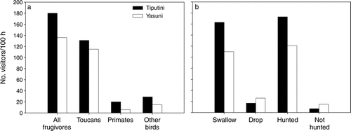

**Figure 1**

Open in figure viewer[PowerPoint](https://esajournals.onlinelibrary.wiley.com/action/downloadFigures?id=i0012-9658-90-6-1449-f01&doi=10.1890%2F08-1332.1)

Visitation frequency to frugivores to *Virola flexuosa* at non-hunted (Tiputini, black bars) and hunted sites (Yasuní, white bars). (a) Differences between sites among observed frugivore groups. (b) Site differences in visitors from species more likely to swallow fruits (*R. tucanus*, *R. vitellinus*, *P. azara*, *P. pluricinctus*, primates, guans, and *B. martii*) or to drop fruits (*P. inscriptus*, *S. reinwardtii*, *Turdus* spp., *C. auratus*, *C. cayana*, *L. vociferans*, *Q. purpurata*, *P. cayana*, *T. cayana*, and *Trogon* spp.) (left side of graph); and site differences for species hunted by local Huaorani (toucans, primates, guans, *B. martii*, *C. auratus*, and *Trogon* spp.; Franzen 2006) and species not harvested (*Turdus* spp., *C. cayana*, *L. vociferans*, *Q. purpurata*, *P. cayana*, and *T. cayana*) (right side of graph).

## Discussion

*Virola flexuosa* is not unique among tropical trees in that it relies entirely on vertebrate seed dispersers to move seeds beyond the canopy. The most effective dispersers, in terms of seed removal, are primates, toucans, and guans, which are disproportionately targeted by Huaorani hunters at our hunted site in Yasuní National Park. Visits to fruiting trees were significantly greater at our non-hunted site than our hunted site. This combined with measurable differences in seed removal based on our seed trap data suggest that dispersal limitation is occurring to a greater degree in a site where large frugivores are hunted.

#### Dispersal limitation

Toucans and primates were not only the most frequent visitors, but also removed the greatest number of seeds relative to other frugivores. Although *V. flexuosa* attracted 20 frugivore species, only half those were responsible for nearly 90% of seed removal. Given the contribution to dispersal by relatively few frugivore species for many tropical trees (this study, Cordeiro and Howe 2003, Russo 2003, Forget and Jansen 2007), the identification and conservation of key dispersers is critical. At a site in Peru, *A. paniscus* was found to remove a remarkable 83% of *V. calophylla* seeds (Russo 2003), highlighting the potential importance of a single frugivore species.

#### Implications of hunting

Reduction in frugivore abundances may alter seed dispersal, seed predation, and seedling recruitment for tropical plants (Pacheco and Simonetti 2000, Wright et al. 2000), potentially resulting in changes of plant species composition and diversity (Wright et al. 2007, Terborgh et al. 2008). Widespread loss of dispersers may eventually result in local extinction of tree species that require dispersal by large-bodied frugivores (Hamann and Curio 1999, Cardoso da Silva and Tabarelli 2000). For example, in northeast Brazil, where larger frugivores including cracids and toucans are threatened by hunting, Cardoso da Silva and Tabarelli (2000) found that at least 31.6% of vertebrate-dispersed trees depend on large-gaped (>15 mm) birds for seed dispersal. Furthermore, they suggested that where key vertebrate dispersers have already been extirpated, seed removal at several tree species is very limited. As our research spans only two years, we are unable to report whether our findings of reduced seed dispersal at YRS are indicative of a continuing trend. However, given the short temporal period over which these changes have likely taken place, one would expect differences in seed removal between TBS and YRS to only increase over the next few years. Also, we recognize that our results are specific only to a single hunted and non-hunted site due to logistic constraints that precluded site replication. Nevertheless, our results are consistent with other studies that show a significantly negative impact of seed removal under conditions of hunting (Wright 2003, Forget and Jansen 2007, Wang et al. 2007) or loss of dispersers through forest fragmentation (Cordeiro and Howe 2003).

#### Frugivore compensation

A consequence of quantitatively restricted seed dispersal at YRS is that seeds reach fewer recruitment sites than expected based on population-level seed production (Schupp et al. 2002). If the majority of seeds fall under the maternal tree, than a greater proportion of that trees' reproductive effort will be used to ensure colonization of a single site, the one the parent tree is occupying; whereas dispersal away ensures arrival and potential recruitment, at a greater number of sites. Understanding, the degree to which dispersal limitation is occurring in tropical forests is increasingly important given the role of vertebrate seed dispersal and acceleration of hunting activities throughout the American, African, and Asian tropics (Fa et al. 2002, Corlett 2007, Peres and Palacios 2007).

## Acknowledgments

We thank C. Cardoni, C. Egan, M. Euaparadorn, C. Fairbanks, E. A. Guevara, J. E. Guevara, J. Klavins, A. Norris, M. Ogburn, A. Van Gunst, and A. Wolf for field assistance. We thank the staff and scientists of Yasuní Research Station and Tiputini Biodiversity Station, Universidad San Francisco de Quito, Pontifica Universidad Católica del Ecuador, Smithsonian Tropical Research Institute, and the Ecuador Ministry of Environment. We are grateful for the support of J. Guerra, D. Romo, K. Swing, C. de Romo, H. Navarette, R. Valencia, L. Baldeon, C. Hernandez, and F. Koester. B. D. Hardesty, P.-M. Forget, and three anonymous reviewers greatly improved the manuscript. The Chapman Memorial Fund, Cleveland Park Zoo, a Fulbright Fellowship, the Lincoln Park Zoo, the Organization for Tropical Studies, a PEO Scholar Award, the Saint Louis Zoo, the Wildlife Conservation Society, a U.S. EPA-STAR Fellowship, and an NSF Dissertation Enhancement Grant (OISE-0400971) provided funding.

## APPENDIX A

Summary of *Virola flexuosa* traits for all study trees including site comparisons ([Ecological Archives E090-096-A1](http://dx.doi.org/10.6084/m9.figshare.c.3301007)).

## APPENDIX B

Number of observed visits to *Virola flexuosa* at Tiputini Biodiversity Station and Yasuní Research Station, Ecuador ([Ecological Archives E090-096-A2](http://dx.doi.org/10.6084/m9.figshare.c.3301007)).

## APPENDIX C

Fate of fruit and seeds of *Virola flexuosa* handled by frugivores comprising >1% of foraging visits ([Ecological Archives E090-096-A3](http://dx.doi.org/10.6084/m9.figshare.c.3301007)).

## Literature Cited

Corresponding Editor: M. Wikelski.

## Citing Literature

[Volume90, Issue6](https://esajournals.onlinelibrary.wiley.com/toc/19399170/2009/90/6)

June 2009

Pages 1449-1455

### Recommended

  [Sophia R. Balcomb](https://esajournals.onlinelibrary.wiley.com/action/doSearch?ContribAuthorRaw=Balcomb%2C+Sophia+R), [Colin A. Chapman](https://esajournals.onlinelibrary.wiley.com/action/doSearch?ContribAuthorRaw=Chapman%2C+Colin+A),

  [Oikos](https://onlinelibrary.wiley.com/journal/16000706)

[Download PDF](https://esajournals.onlinelibrary.wiley.com/doi/pdf/10.1890/08-1332.1)

[back](https://esajournals.onlinelibrary.wiley.com/doi/full/10.1890/08-1332.1)